# An exploration of dingo observations in the ALA

Dingoes are the subject of ongoing debate about whether they should be considered a protected species or a pest species. Here we explore dingo observations in the ALA to understand how differing attitudes affect dingo data, plotting spatial and temporal trends using {ggplot2}.

Eukaryota

Animalia

Mammalia

Summaries

Maps

R

Intern-post

Authors

Amos Smith

Dax Kellie

Published

May 16, 2023

Modified

October 23, 2026

#### Author

Amos Smith [Olivia Torresan](https://labs.ala.org.au/about/Torresan_Olivia/index.html)  
[Dax Kellie](https://labs.ala.org.au/about/Kellie_Dax/index.html)

#### Date

5 May 2023

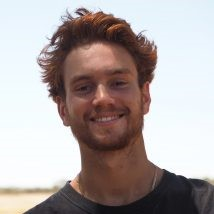

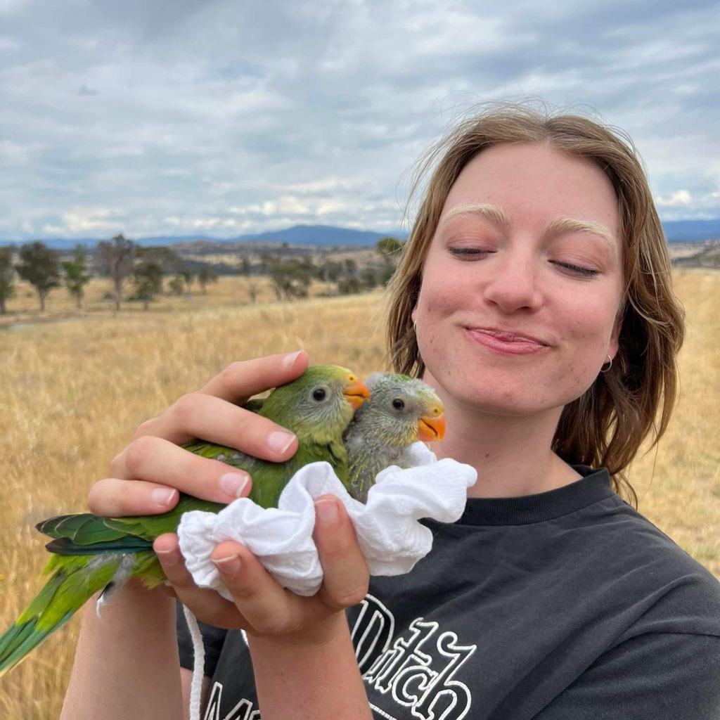

**TipIntern Post**

The dingo (*Canis familiaris*) is among Australia’s most recognisable species internationally. However, debate continues about whether dingoes are considered invasive or native species.

Dingoes arrived in Australia [around 3,000–5,000 years ago](https://www.nature.com/articles/s41598-018-28324-x), and their rapid dispersal was likely [facilitated by humans](https://www.nature.com/articles/s41598-018-28324-x#:~:text=Some%20idea%20of,already%20acquired%20dogs.). Dingoes [hold great significance](https://www.nma.gov.au/defining-moments/resources/arrival-of-the-dingo#:~:text=Dingo%20in%20First,away%20malevolent%20spirits.) to many Aboriginal and Torres Strait Islander communities. In some communities, women and children often [took dingoes with them](https://www.americanscientist.org/article/the-elusive-dingo) to hunt small game or collect food, regarded as protection from danger.

In the present day, dingoes negatively impact livestock producers, especially sheep farmers. To reduce these impacts, landowners and government agencies spend an estimated [~$30 million annually across Australia](https://www.publish.csiro.au/wr/pdf/WR19030) to control dingo populations. Control methods include using traps, baits and shooting, along with constructing a physical barrier to limit their movement: the Dog Fence (also known as the Dingo Fence).

To understand the debate about the dingo’s role in Australia’s ecosystems, it’s useful to know the species’ current distribution. Here, we’ll explore where and how often dingo observations are recorded in the Atlas of Living Australia (ALA) to understand how historical and ongoing differences in attitudes toward dingo conservation affect data collection.

# Summarise observations

Let’s start by finding how many observations of dingoes are in the ALA and where they are.

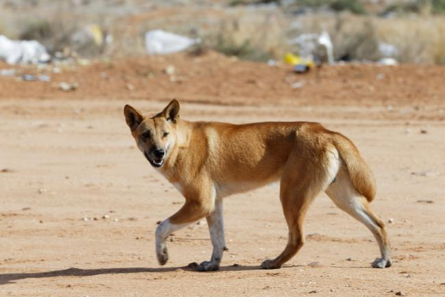

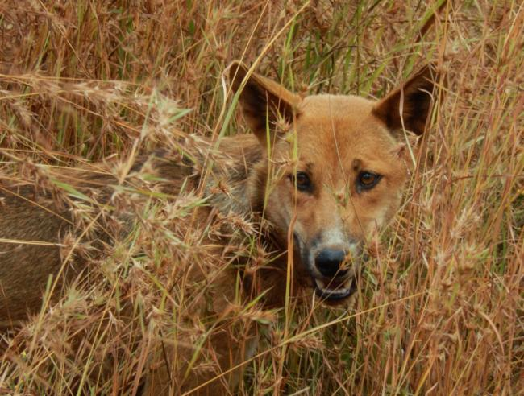

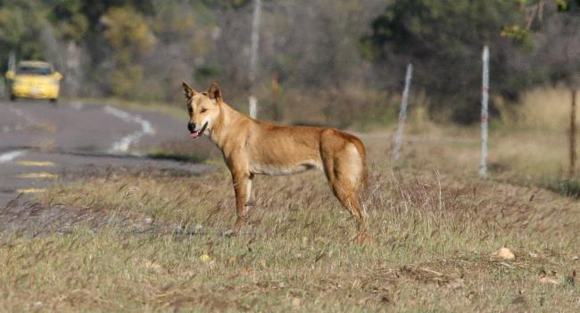

Left: [*Canis familiaris* (Michael Hains CC-BY-NC 3.0 (Au)](https://biocache.ala.org.au/occurrences/4d4a1b5d-f70f-4286-9282-3c325cdf2646), Middle: [*Canis familiaris* (GibberGavin CC-BY-NC 4.0 (Int))](https://biocache.ala.org.au/occurrences/24b77a44-2a8d-4d16-a4e3-41823d1fc8ca), Right: [*Canis familiaris* (Danial Moore CC-BY-NC 3.0 (Au))](https://biocache.ala.org.au/occurrences/64cc4167-9f4f-495c-b4be-b0a5e2ca57de)

```r
# packages
library(galah)
library(tidyverse)
library(ozmaps)
library(sf)
library(patchwork)
library(here)
library(rmapshaper)
library(ggpointdensity)
library(glue)
library(ggtext)
library(viridis)
```

## Records by state

### Find fields to filter data

We’ll use the [{galah} package](http://galah.ala.org.au/) to download our data.

The taxonomic name for dingoes—*Canis familiaris*—is broadly the name for all wild dogs, though recent genomic research has found pure dingoes are [genomically distinct from wild dogs](https://www.abc.net.au/news/rural/2022-04-23/dingo-or-feral-dog-science-advances-genetic-sequence/101010896)[^2]. This means that if we search using the scientific name *Canis familiaris*, we’ll likely return more than just dingo records. To fix this, let’s filter our records to those specified by the data provider with the common name “Dingo”.

Let’s use `search_fields()` to help us find which fields we can use to filter the taxonomic name. There are a few options, but the `raw_vernacularName` field seems to hold original common names specified by data providers.

```r
search_fields("common name")
```

```
# A tibble: 1 × 3
  id                 description               type
  <chr>              <chr>                     <chr>
1 raw_vernacularName Common name (unprocessed) fields
```

```r
search_fields("raw_vernacularName") |> search_values("dingo")
```

```
# A tibble: 4 × 1
  raw_vernacularName
  <chr>
1 Dingo
2 Dingo, domestic dog
3 dingo
4 Undetermined, Dingo or Dog
```

We can use the same method to find a field that contains states & territories.

```r
search_fields("australian states")
```

```
# A tibble: 2 × 3
  id     description                            type
  <chr>  <chr>                                  <chr>
1 cl2013 ASGS Australian States and Territories fields
2 cl22   Australian States and Territories      fields
```

```r
search_fields("cl22") |> show_values()
```

```
# A tibble: 11 × 1
   cl22
   <chr>
 1 New South Wales
 2 Victoria
 3 Queensland
 4 Western Australia
 5 South Australia
 6 Northern Territory
 7 Tasmania
 8 Australian Capital Territory
 9 Macquarie Island
10 Coral Sea Islands
11 Ashmore and Cartier Islands
```

### Download counts

We’ll download the number of dingo observations in each state/territory with `atlas_counts()` and arrange the resulting counts in descending order.

```r
dingo_counts <- galah_call() |>
  galah_identify("canis familiaris") |>
  galah_filter(raw_vernacularName == c("Dingo", "dingo")) |>
  galah_group_by(cl22) |>
  atlas_counts() |>
  arrange(desc(count))

dingo_counts |> gt::gt()
```

| cl22 | count |
| --- | --- |
| Northern Territory | 11565 |
| Western Australia | 4963 |
| Victoria | 3371 |
| South Australia | 3036 |
| New South Wales | 2756 |
| Queensland | 1555 |
| Australian Capital Territory | 421 |

## Data providers

Next let’s find out who the main data providers are of dingo observations to see whether observations come from citizen science programs or state monitoring programs. We’ll filter to only display providers that have provided more than 5 observations of dingoes.

```r
data_providers <- galah_call() |>
  galah_identify("canis familiaris") |>
  galah_filter(raw_vernacularName == c("Dingo", "dingo")) |>
  galah_group_by(dataResourceName)|>
  galah_apply_profile(ALA) |>
  atlas_counts()

counts_filtered <- data_providers |>
  filter(count > 5)
```

```
# A tibble: 15 × 2
   dataResourceName                                           count
   <chr>                                                      <int>
 1 Fauna Atlas N.T.                                            8522
 2 AWC Ecological Monitoring Surveys                           6719
 3 Victorian Biodiversity Atlas                                3058
 4 SA Fauna                                                    2939
 5 NSW BioNet Atlas                                            2467
 6 Australian National Wildlife Collection provider for OZCAM  2035
 7 WildNet - Queensland Wildlife Data                          1263
 8 ACT Wildlife Atlas                                           319
 9 NatureMapr                                                   165
10 Observation.org, Nature data from around the World            43
11 ALA species sightings and OzAtlas                             31
12 Northern Gulf Fauna Survey                                    18
13 Australian Museum provider for OZCAM                          12
14 Encyclopedia of Life Images - Flickr Group                     8
15 Museums Victoria provider for OZCAM                            6
```

### Download observations

We can check to see where each data provider’s observations are recorded. We’ll download dingo observations using `atlas_occurrences()`. Then we’ll filter our observations to only those supplied by providers in `counts_filtered`.

You will need to first provide a [registered email with the ALA](https://auth.ala.org.au/userdetails/registration/createAccount) using `galah_config()` before retrieving records.

```r
# Use a ALA-registered email (register at ala.org.au)
galah_config(email = "your-email-here")
```

```r
dingo_obs <- galah_call()|>
  galah_identify("canis familiaris") |>
  galah_filter(raw_vernacularName == c("Dingo", "dingo")) |>
  galah_apply_profile(ALA) |>
  atlas_occurrences()
```

```
Retrying in 1 seconds.
Retrying in 2 seconds.
```

```r
points_filtered <- dingo_obs |>
  filter(dataResourceName %in% counts_filtered$dataResourceName)
```

```
# A tibble: 27,605 × 9
   recordID       scientificName taxonConceptID decimalLatitude decimalLongitude
   <chr>          <chr>          <chr>                    <dbl>            <dbl>
 1 0003be4b-e6fd… Canis familia… https://biodi…           -34.3             150.
 2 0006dbad-2cff… Canis familia… https://biodi…           -13.5             132.
 3 0006dc99-2c9d… Canis familia… https://biodi…           -25.2             132.
 4 0007bc84-7602… Canis familia… https://biodi…           -12.7             133.
 5 000a95fc-2d1b… Canis familia… https://biodi…           -13.6             132.
 6 000b4d9d-165c… Canis familia… https://biodi…           -12.8             131.
 7 000cea4e-96ed… Canis familia… https://biodi…           -36.9             148.
 8 000d0a83-e7e0… Canis familia… https://biodi…           -16.5             136.
 9 000eba95-8623… Canis familia… https://biodi…           -17.2             127.
10 00126e5b-db91… Canis familia… https://biodi…           -36.9             148.
# ℹ 27,595 more rows
# ℹ 4 more variables: eventDate <dttm>, basisOfRecord <chr>,
#   occurrenceStatus <chr>, dataResourceName <chr>
```

### Visualise

We can create a bar plot and a map of observations to visualise our results.

```r
custom_colours <- c(
  "Museums Victoria provider for OZCAM" = "#604830",
  "Victorian Biodiversity Atlas" = "#486030",
  "Australian National Wildlife Collection provider for OZCAM" = "#6090d8",
  "NSW BioNet Atlas" = "#604830",
  "WildNet - Queensland Wildlife Data" = "#6fab3f",
  "SA Fauna (BDBSA)" = "#d89060",
  "Australian Museum provider for OZCAM" = "#FFC300",
  "Fauna Atlas N.T." = "#a84830"
)

# Bar plot
bar_plot <- counts_filtered |>
  ggplot(aes(
    x = reorder(str_wrap(dataResourceName, 35), count),
    y = count, fill = dataResourceName)) +
  geom_bar(stat = "identity") +
  scale_fill_manual(values = custom_colours) +
  scale_x_discrete(expand = c(0, 0)) +
  scale_y_continuous(labels = scales::label_comma()) +
  coord_flip() +
  xlab("") +
  pilot::theme_pilot(grid = "v",
                     axes = "b") +
  theme(legend.position = "none",
        axis.text = element_text(size = 12))

# Map
aus <- ozmap_data(data = "states")

map <- ggplot() +
  geom_sf(data = aus, fill = "#FBFBEF") +
  geom_point(
    data = points_filtered,
    mapping = aes(
      x = decimalLongitude,
      y = decimalLatitude,
      colour = dataResourceName),
    alpha = 0.5) +
  scale_color_manual(values = custom_colours) +
  theme_void() +
  coord_sf(
    ylim = c(-45, -10),
    xlim = c(110, 155)) +
  theme(legend.position = "none")
```

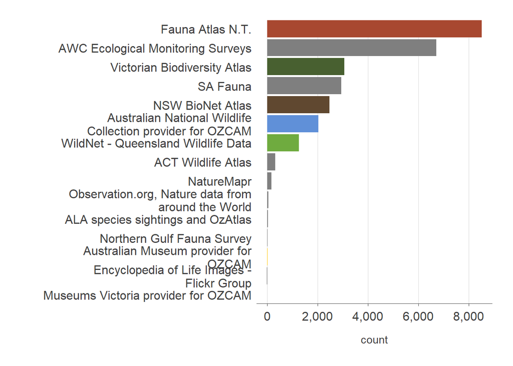

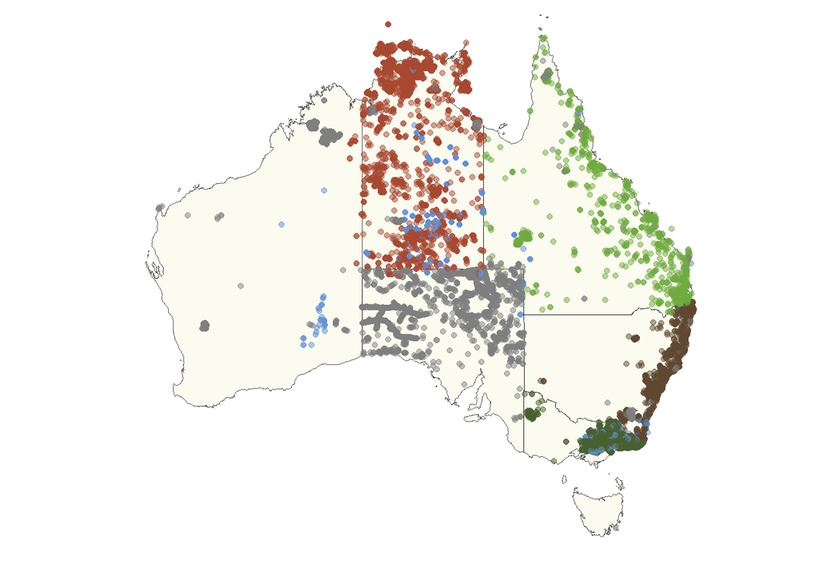

## Time of year

### Download data

First we’ll download observations by month in the Northern Territory by using the `month` field inside `galah_group_by()`.

```r
# download data
dingo_NT <- galah_call() |>
  galah_identify("canis familiaris") |>
  galah_filter(raw_vernacularName == c("Dingo", "dingo"),
               cl22 == "Northern Territory") |>
  galah_group_by(month) |>
  atlas_counts()
```

```
# A tibble: 12 × 2
   month count
   <chr> <int>
 1 7      1460
 2 6      1285
 3 8       956
 4 9       917
 5 5       817
 6 10      724
 7 11      580
 8 4       495
 9 3       423
10 12      332
11 1       315
12 2       250
```

We’ll use the `lubridate::month()` function to convert the class of our `month` column from `character` to `ordered` `factor`.

```r
# format months for plotting
month_NT <- dingo_NT |>
  mutate(
    month = lubridate::month(as.numeric(month), label = TRUE) # format month
    )
```

```
# A tibble: 12 × 2
   month count
   <ord> <int>
 1 Jul    1460
 2 Jun    1285
 3 Aug     956
 4 Sep     917
 5 May     817
 6 Oct     724
 7 Nov     580
 8 Apr     495
 9 Mar     423
10 Dec     332
11 Jan     315
12 Feb     250
```

### Make bar plot

Now we can make a bar chart to see observations over the year. We’ll do the same for South Australia, too.

Northern Territory’s dingo observations are recorded mainly over winter months (June–August). Alternatively, South Australia’s dingo observations are mainly recorded during autumn months (April–June).

```r
# Northern Territory plot
barplot_nt <- ggplot(data = month_NT,
                     aes(x = month, y = count)) +
  geom_bar(stat = "identity", fill = "#a84830") +
  labs(title = "Northern Territory",
       x = "Month",
       y = "No. of observations") +
  scale_x_discrete(expand = c(0,0)) +
  scale_y_continuous(limits = c(0, 1500),
                     expand = c(0,0)) +
  pilot::theme_pilot(grid = "h")
```

```r
## South Australia

# download data
dingo_SA <- galah_call() |>
  galah_identify("canis familiaris") |>
  galah_filter(raw_vernacularName == c("Dingo", "dingo"),
               cl22 == "South Australia") |>
  galah_group_by(month) |>
  atlas_counts() |>
  mutate(
    month = month(as.numeric(month), label = TRUE) # format month
    )

# plot
barplot_sa <- ggplot(data = dingo_SA,
       aes(x = month, y = count)) +
  geom_bar(stat = "identity", fill = "#d89060") +
  labs(title = "South Australia",
       x = "Month",
       y = "No. of observations") +
  scale_x_discrete(expand = c(0,0)) +
  scale_y_continuous(limits = c(0, 1500),
                     expand = c(0,0)) +
  pilot::theme_pilot(grid = "h")
```

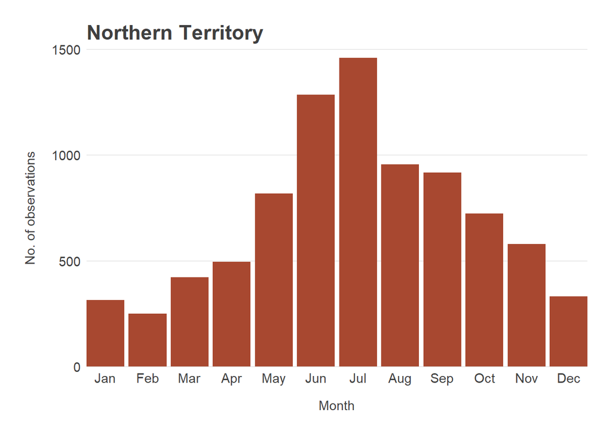

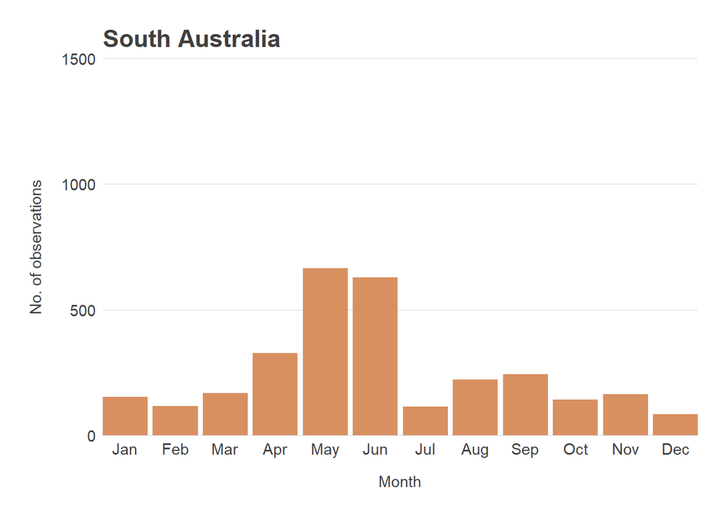

Does this suggest dingoes are more active during winter, or are data collectors surveying during cooler times of the year? The answer might be “both”. One dingo tracking research study found that dingoes are far more active in winter, [spending 46% of their day stationary in winter compared to 91% of their day in summer](https://movementecologyjournal.biomedcentral.com/articles/10.1186/s40462-021-00246-w). Similarly, it’s easier for data collectors to survey during winter months when the heat is less extreme. Cooler winter temperatures might allow dingoes *and* surveyors to be more active, increasing the likelihood of incidental observations.

# Dingo observations in nationally protected areas

In the Northern Territory and South Australia, dingoes are protected within nationally protected areas. Does this mean that the majority of observations are recorded within these areas? To answer this question, let’s map locations of dingo observations over protected areas using the [Collaborative Australian Protected Areas Database (CAPAD)](https://www.environment.gov.au/fed/catalog/search/resource/details.page?uuid=%7B4448CACD-9DA8-43D1-A48F-48149FD5FCFD%7D).

## Northern Territory

### Download CAPAD shapefile

We’ll first need the CAPAD shapefile. We can get it by downloading the CAPAD2020_terrestrial.zip folder [from their website](https://www.environment.gov.au/fed/catalog/search/resource/downloadData.page?uuid=%7B4448CACD-9DA8-43D1-A48F-48149FD5FCFD%7D). Download and save this folder in your R Project or working directory and unzip it.

```r
# read in capad shapefile
capad <- st_read(here("posts",
                      "data",
                      "CAPAD",
                      "CAPAD2020_terrestrial.shp"),
                 quiet = TRUE) |>
  ms_simplify(keep = 0.1) |>
  st_transform(crs = st_crs("WGS84")) |>
  st_make_valid()
```

We will filter our CAPAD layer to only the Northern Territory for our plot.

```r
# filter to NT
capad_nt <- capad |>
  filter(STATE == "NT")
```

### Download records

Now we can download dingo observations in the Northern Territory (and remove any NAs with `drop_na()`).

```r
# download dingo observations in NT
dingo_obs_nt <- galah_call() |>
  galah_identify("canis familiaris") |>
  galah_filter(raw_vernacularName == c("Dingo", "dingo"),
               cl22 == "Northern Territory") |>
  atlas_occurrences() |>
  drop_na() # filter any NA values out
```

```
Retrying in 1 seconds.
```

```
# A tibble: 8,554 × 9
   recordID       scientificName taxonConceptID decimalLatitude decimalLongitude
   <chr>          <chr>          <chr>                    <dbl>            <dbl>
 1 0006dbad-2cff… Canis familia… https://biodi…           -13.5             132.
 2 0006dc99-2c9d… Canis familia… https://biodi…           -25.2             132.
 3 000a95fc-2d1b… Canis familia… https://biodi…           -13.6             132.
 4 001643af-0fbd… Canis familia… https://biodi…           -11.2             130.
 5 001bded1-70cb… Canis familia… https://biodi…           -25.7             135.
 6 002857f8-8a36… Canis familia… https://biodi…           -12.8             134.
 7 002b752e-dc4c… Canis familia… https://biodi…           -12.3             133.
 8 002dda9a-f20e… Canis familia… https://biodi…           -14.3             131.
 9 00306071-b94f… Canis familia… https://biodi…           -11.8             131.
10 00318f5d-f2bc… Canis familia… https://biodi…           -15.5             130.
# ℹ 8,544 more rows
# ℹ 4 more variables: eventDate <dttm>, basisOfRecord <chr>,
#   occurrenceStatus <chr>, dataResourceName <chr>
```

### Make map

We’ll make our map of the Northern Territory by plotting each of our components and adding a colour scale to indicate places where there is more than one observation in a single point.

```r
# make map
nt_plot <- ggplot() +
  geom_sf(data = ozmap_states |> filter(NAME == "Northern Territory"),
          fill = "#F8FBEF",
          colour = "grey60",
          linewidth = 0.3) +
  geom_pointdensity(data = dingo_obs_nt,
                    mapping = aes(x = decimalLongitude,
                                  y = decimalLatitude),
                    size = 2.4,
                    alpha = 0.6) +
  geom_sf(data = capad_nt,
          fill = "#1F901F",
          colour = "#1F901F",
          linewidth = 0.5,
          alpha = 0.2,
          linetype = "dashed") +
  scale_color_viridis(option = "D",
                      direction = -1,
                      begin = 0.0,
                      end = 0.4,
                      guide = guide_colorbar(title = ("Number of overlapping observations"),
                                     title.position = "top",
                                     title.hjust = 0.5)) +
  theme_void() +
  theme(legend.position = "bottom",
        legend.title = element_text(face = "bold"),
        legend.key.width = unit(15, 'mm'),
        plot.margin = unit(c(1,0,1,0),"cm"))
```

### Add coloured title

Finally, we can avoid adding more than one legend by using colour in our title to specify the colour of protected areas and dingo observations on our map (using a [clever method by Cara Thompson](https://twitter.com/cararthompson/status/1539662532608020480)). We’ll need to use `ggnewscale::new_scale_color()` to add our custom colour palette for our text because we are already using another colour palette for our observation points (you can check out our [previous post on using {ggnewscale}](https://labs.ala.org.au/posts/2022-05-23-ggnewscale/post.html) to learn more).

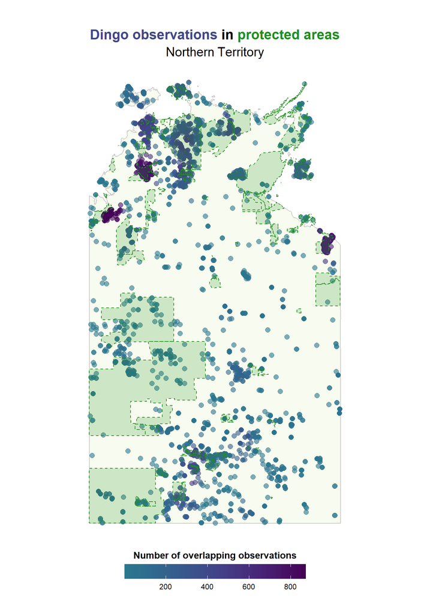

```r
# create palette for title
dingo_palette <- list("protected" = "#1F901F",
                      "obs" = "#404788")

nt_plot +
  ggnewscale::new_scale_color() +
  scale_colour_manual(values = dingo_palette) +
  labs(
    title = glue(
      "<span style='color:{dingo_palette$obs}'>Dingo observations</span> in
      <span style='color:{dingo_palette$protected}'>**protected areas**</span>"),
    subtitle = "Northern Territory") +
  theme(plot.title = element_markdown(face = "bold", size = 16, hjust = 0.5),
        plot.subtitle = element_markdown(hjust = 0.5, size = 15))
```

### Calculate proportion inside protected areas

By comparing the number of records in CAPAD areas to the total observations in Northern Territory, we find that more than half of all dingo observations are recorded inside of protected areas.

**Tip**

Searching for CAPAD fields in {galah} shows us that {galah} has the CAPAD 2020 layer available for us to use in a query.

```r
search_all(fields, "capad") |> print(n = 5)
```

```
# A tibble: 13 × 3
  id      description            type
  <chr>   <chr>                  <chr>
1 cl10944 CAPAD 2016 Terrestrial fields
2 cl10945 CAPAD 2016 Marine      fields
3 cl10957 CAPAD 2018 Marine      fields
4 cl11001 CAPAD 2024 Marine      fields
5 cl11019 CAPAD Terrestrial 2024 fields
# ℹ 8 more rows
```

We can return the number of dingo observations in *each* CAPAD area by using `galah_group_by(cl11033)` in our query. Adding the observation counts together will give us the total observations in CAPAD areas.

```r
# Download dingo record counts inside CAPAD areas
dingo_capad_nt <- galah_call() |>
  galah_identify("canis familiaris") |>
  galah_filter(raw_vernacularName == c("Dingo", "dingo"),
               cl22 == "Northern Territory") |>
  galah_group_by(cl11033) |> # capad
  atlas_counts() |>
  drop_na() # filter any NA values out

# Proportion inside vs outside of protected areas
in_protected <- dingo_capad_nt|> summarise(total = sum(count))
out_of_protected <- nrow(dingo_obs_nt)

paste(round(in_protected / out_of_protected * 100, 2), "%", sep = "")
```

```
[1] "73.47%"
```

## South Australia

Let’s do the same as above to make a map of South Australia.

We’ll also include a map of where the Dog Fence is within South Australia to compare observations on either side of the fence. We obtained a shapefile of the Dog Fence by contacting the [Department of Primary Industries and Regions](https://pir.sa.gov.au/biosecurity/introduced-pest-feral-animals/find_a_pest_animal/wild_dogs_and_dingoes/dog_fence).

```r
dog_fence <- st_read(here("posts",
                          "data",
                          "Dog Fence",
                          "Dog_Fence.shp"),
                     quiet = TRUE) |>
  ms_simplify(keep = 0.1) |>
  st_transform(crs = st_crs("WGS84")) |>
  st_make_valid()
```

The Dog Fence is labelled in our map below. There are noticeably fewer observations recorded of dingoes on the southern side of the fence, and those that are recorded appear to be mostly inside protected areas.

```r
# filter to SA
capad_sa <- capad |>
  filter(STATE == "SA")

# download dingo observations in SA
dingo_obs_sa <- galah_call() |>
  galah_identify("canis familiaris") |>
  galah_filter(raw_vernacularName == c("Dingo", "dingo"),
               cl22 == "South Australia") |>
  atlas_occurrences() |>
  drop_na() # filter any NA values out
```

```
Retrying in 1 seconds.
```

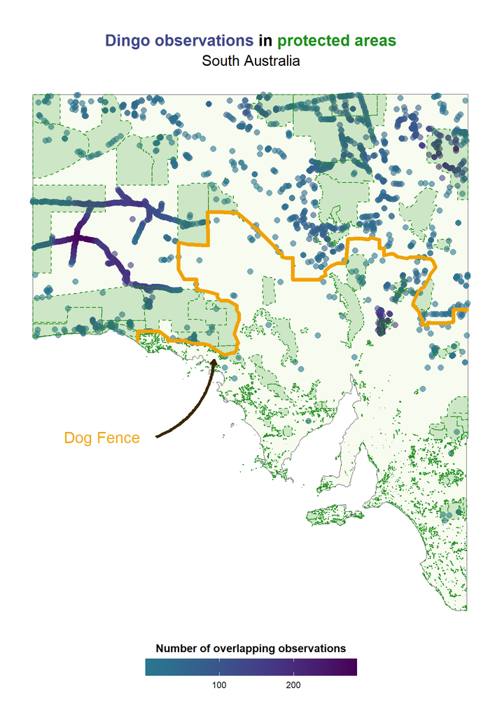

```r
# Start and end points of arrow
arrow <-
  tibble(
    x1 = c(132.4),
    x2 = c(134),
    y1 = c(-34),
    y2 = c(-32.2))

# make map
sa_plot <- ggplot() +
  geom_sf(data = ozmap_states |> filter(NAME == "South Australia"),
          fill = "#F8FBEF",
          colour = "grey60",
          linewidth = 0.5) +
  geom_pointdensity(data = dingo_obs_sa,
                    mapping = aes(x = decimalLongitude,
                                  y = decimalLatitude),
                    size = 2.4,
                    alpha = 0.6) +
  geom_sf(data = capad_sa,
          fill = "#1F901F",
          colour = "#1F901F",
          linewidth = 0.5,
          alpha = 0.2,
          linetype = "dashed") +
  geom_sf(data = dog_fence, color = "#F0A202", linewidth = 1.8) +
  geom_curve(
    data = arrow, aes(x = x1, y = y1, xend = x2, yend = y2),
    arrow = arrow(length = unit(0.08, "inch")),
    colour = "#392704",
    linewidth = 1.5,
    curvature = 0.3) +
  annotate("text", x = 130.9, y = -34, label = "Dog Fence", size = 5.5, colour = "#EFA81A") +
  scale_color_viridis(option = "D",
                      direction = -1,
                      begin = 0.0,
                      end = 0.4,
                      guide = guide_colorbar(title = ("Number of overlapping observations"),
                                     title.position = "top",
                                     title.hjust = 0.5)) +
  theme_void() +
  theme(legend.position = "bottom",
        legend.title = element_text(face = "bold"),
        legend.key.width = unit(15, 'mm'),
        plot.margin = unit(c(1,0,1,0),"cm"))

# add title
sa_plot +
  ggnewscale::new_scale_color() +
  scale_colour_manual(values = dingo_palette) +
  labs(
    title = glue(
      "<span style='color:{dingo_palette$obs}'>Dingo observations</span> in
      <span style='color:{dingo_palette$protected}'>**protected areas**</span>"),
    subtitle = "South Australia") +
  theme(plot.title = element_markdown(face = "bold", size = 16, hjust = 0.5),
        plot.subtitle = element_markdown(hjust = 0.5, size = 15))
```

By comparing the number of records in CAPAD areas to the total observations in South Australia, we find that around 4 in 10 dingo observations are recorded inside of protected areas.

```r
# Download dingo record counts inside CAPAD areas
dingo_capad_sa <- galah_call() |>
  galah_identify("canis familiaris") |>
  galah_filter(raw_vernacularName == c("Dingo", "dingo"),
               cl22 == "South Australia") |>
  galah_group_by(cl11033) |> # capad
  atlas_counts() |>
  drop_na() # filter any NA values out

# Proportion inside vs outside of protected areas
in_protected <- dingo_capad_sa |> summarise(total = sum(count))
out_of_protected <- nrow(dingo_obs_sa)

paste(round(in_protected / out_of_protected * 100, 2), "%", sep = "")
```

```
[1] "39.14%"
```

# Final thoughts

One possible explanation could be due to differences in legislation between states. The Northern Territory is one of only two states/territories that [recognises dingoes as a protected species](https://nt.gov.au/environment/animals/feral-animals/wild-dog#:~:text=Dingoes%20are%20protected%20in%20the,take%20or%20interfere%20with%20wildlife.) (the other is [Victoria](https://www.wildlife.vic.gov.au/our-wildlife/dingoes)). In these states, there are likely surveys or programs in place to collect data to maintain their distribution for conservation.

However, South Australia is one of several states with a mixed wild dog control policy, where wild dogs and dingoes are [controlled in some areas and protected in others](https://pir.sa.gov.au/biosecurity/introduced-pest-feral-animals/find_a_pest_animal/wild_dogs_and_dingoes)[^3]. Similar mixed policy strategies exist in [New South Wales](https://www.environment.nsw.gov.au/topics/parks-reserves-and-protected-areas/park-policies/wild-dogs) and [Queensland](https://www.business.qld.gov.au/industries/farms-fishing-forestry/agriculture/biosecurity/animals/invasive/wild-dogs/law), while in Western Australia dingoes are [classified as a pest species](https://www.agric.wa.gov.au/state-barrier-fence/wild-dogs) and required to be controlled. In these states, there is a risk that control methods sometimes take precedence over data collection, despite monitoring programs being in place. Still, there are lots of dingo observations recorded in South Australia, suggesting that legislation explains some but not all of the trends we see in the data.

Ultimately, dingoes are currently listed as [vulnerable to extinction under the IUNC’s Red List of Threatened Species](https://www.iucnredlist.org/species/41585/10484199). Those interested in estimating the dingo’s current distribution may have to be mindful that the accuracy of estimates may depend on where data were collected.

## Footnotes

[^1]: Some research suggests dingoes might [not always benefit mammal species richness](https://www.sciencedirect.com/science/article/pii/S0006320720306960).
[^2]: However, all wild dogs in Australia [possess some percentage of dingo genes](https://newsroom.unsw.edu.au/news/science-tech/dogs-not-gone-wild-dna-tests-show-most-wild-dogs-australia-are-pure-dingoes).
[^3]: [In South Australia](https://pir.sa.gov.au/biosecurity/introduced-pest-feral-animals/find_a_pest_animal/wild_dogs_and_dingoes), inside the Dog Fence landholders have a legal responsibility to control wild dogs—including dingoes—on their properties, whereas outside of the Dog Fence dingoes are listed as unprotected native wildlife.

The ALA is made possible by contributions from its partners, is supported by [NCRIS](https://www.education.gov.au/national-collaborative-research-infrastructure-strategy-ncris), is hosted by [CSIRO](https://csiro.au/), and is the Australian node of [GBIF](https://www.gbif.org/en/).

**Acknowledgement of Traditional Owners and Country**

The Atlas of Living Australia acknowledges Australia's Traditional Owners and pays respect to the past and present Elders of the nation's Aboriginal and Torres Strait Islander communities. We honour and celebrate the spiritual, cultural and customary connections of Traditional Owners to country and the biodiversity that forms part of that country.

This work is licensed under a [Creative Commons Attribution 3.0 Australia License](https://creativecommons.org/licenses/by/3.0/au/)

[Copyright](https://www.ala.org.au/terms-of-use#cy) [Terms of Use](https://www.ala.org.au/terms-of-use) [System Status](https://status.ala.org.au/)